# LendingClub_DecisionTrees

```python
import numpy as np
import pandas as pd
import matplotlib.pyplot as plt
import seaborn as sns
sns.set()  #if you want to use seaborn themes with matplotlib functions
import warnings
warnings.filterwarnings('ignore')
rand_state = 1000
```

To start, let's import the data and see what we're working with

```python
df = pd.read_csv("lendingclub.csv")
df_raw = df
df.head()
```

|  | home_ownership | income | dti | fico | loan_status |
| --- | --- | --- | --- | --- | --- |
| 0 | 1 | 43.0 | 39.66 | 670 | 0 |
| 1 | 1 | 80.0 | 39.54 | 685 | 1 |
| 2 | 0 | 30.0 | 39.52 | 695 | 1 |
| 3 | 1 | 105.0 | 39.45 | 710 | 0 |
| 4 | 0 | 28.6 | 39.28 | 680 | 1 |

Now let's do some preprocessing to make sure there isn't anything funky going on that will mess with our results.

```python
df.isna().sum()
```

```
home_ownership    0
income            0
dti               0
fico              0
loan_status       0
dtype: int64
```

What a beautiful row of zeros.

```python
df.info()
```

```
<class 'pandas.core.frame.DataFrame'>
RangeIndex: 2270 entries, 0 to 2269
Data columns (total 5 columns):
 #   Column          Non-Null Count  Dtype
---  ------          --------------  -----
 0   home_ownership  2270 non-null   int64
 1   income          2270 non-null   float64
 2   dti             2270 non-null   float64
 3   fico            2270 non-null   int64
 4   loan_status     2270 non-null   int64
dtypes: float64(2), int64(3)
memory usage: 88.8 KB
```

```python
for col in df.columns:
    print(col, df[col].nunique())
```

```
home_ownership 2
income 470
dti 1617
fico 34
loan_status 2
```

A couple of these variables make more sense as categorical variables rather than int/object. Let's change those.

```python
categorical = ['home_ownership', 'loan_status']

for col in categorical:
    df[col] = df[col].astype("category")
```

```python
df.info()
```

```
<class 'pandas.core.frame.DataFrame'>
RangeIndex: 2270 entries, 0 to 2269
Data columns (total 5 columns):
 #   Column          Non-Null Count  Dtype
---  ------          --------------  -----
 0   home_ownership  2270 non-null   category
 1   income          2270 non-null   float64
 2   dti             2270 non-null   float64
 3   fico            2270 non-null   int64
 4   loan_status     2270 non-null   category
dtypes: category(2), float64(2), int64(1)
memory usage: 57.9 KB
```

Looking much better!

Let's take an overall look at the data to get an idea of what we're working with.

```python
df.describe().T
```

|  | count | mean | std | min | 25% | 50% | 75% | max |
| --- | --- | --- | --- | --- | --- | --- | --- | --- |
| income | 2270.0 | 74.058571 | 39.335066 | 20.00 | 46.0000 | 65.00 | 92.0000 | 250.00 |
| dti | 2270.0 | 18.907824 | 8.460242 | 0.74 | 12.6175 | 18.42 | 25.2875 | 39.66 |
| fico | 2270.0 | 692.504405 | 28.854947 | 660.00 | 670.0000 | 685.00 | 705.0000 | 845.00 |

It looks like there's an outlier in income - we'll want to keep an eye out for that when we run our model.

```python
for col in ['loan_status']:
    print(df[col].value_counts())
```

```
1    1474
0     796
Name: loan_status, dtype: int64
```

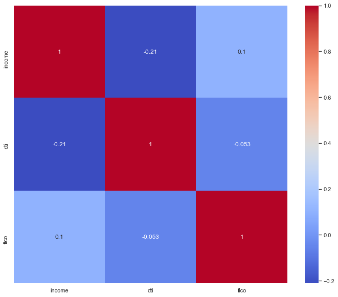

```python
plt.figure(figsize=(12,10))
sns.heatmap(df.corr(), cmap='coolwarm',annot=True)
plt.show()
```

The debt to income ratio and income are negatively correlated, which is expected as debts don't typically increase in the same proportion as income. FICO score and income are positively correlated, which is also not surprising since individuals with higher income are typically more financially literate.

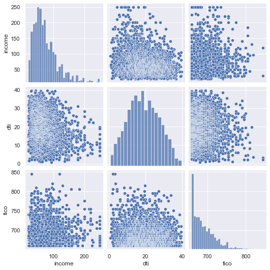

```python
sns.pairplot(df[['income', 'dti','fico']])
plt.show()
```

There does seem to be more data for individuals with lower FICO scores and income, but otherwise there don't seem to be any strong relationships that stand out in the pair plot.

Overall it doesn't seem like there is anything unexpected going on in this dataset, other than an outlier that we'll need to keep an eye on.

```python
#for some reason it wouldn't let us look at that breakdown
#of loan_status so we had to do this
loanstatus = df['loan_status']
```

```python
pd.crosstab(loanstatus,loanstatus, normalize='all')*100
```

| loan_status | 0 | 1 |
| --- | --- | --- |
| 0 | 35.066079 | 0.000000 |
| 1 | 0.000000 | 64.933921 |

The ratio of good condition loans vs default loans is relatively balanced.

```python
y = df['loan_status']
X = df.drop('loan_status', axis=1) # becareful inplace= False
from sklearn.model_selection import train_test_split
X_train, X_test, y_train, y_test = train_test_split(X, y, test_size=0.2, random_state=rand_state)
```

```python
from sklearn.tree import DecisionTreeClassifier
```

```python
Tree_classifier = DecisionTreeClassifier()
Tree_classifier.fit(X_train, y_train)
```

```
DecisionTreeClassifier()
```

```python
y_hat = Tree_classifier.predict(X_test)
```

```python
from sklearn.metrics import accuracy_score, recall_score, precision_score, f1_score
from sklearn.metrics import confusion_matrix, classification_report, roc_curve, roc_auc_score
```

```python
print(confusion_matrix(y_test, y_hat))
```

```
[[ 59 101]
 [117 177]]
```

```python
print(classification_report(y_test, y_hat))
```

```
              precision    recall  f1-score   support

           0       0.34      0.37      0.35       160
           1       0.64      0.60      0.62       294

    accuracy                           0.52       454
   macro avg       0.49      0.49      0.49       454
weighted avg       0.53      0.52      0.52       454
```

```python
path = DecisionTreeClassifier().cost_complexity_pruning_path(X_train,y_train)
```

```python
path
```

[output not shown]

[output cut: 31 more lines]

[output not shown]

```python
ccp_alphas = path.ccp_alphas
```

```python
from sklearn.model_selection import cross_val_score
import sklearn.metrics
```

```python
accuracy_cv =[]
for alpha in ccp_alphas:
    accuracy = cross_val_score(estimator = DecisionTreeClassifier(ccp_alpha=alpha), X = X_train, y = y_train, cv = 5 , scoring="accuracy" )
    accuracy_cv.append(np.mean(accuracy))

output = pd.DataFrame(list(ccp_alphas), columns=['alpha'])
output['accuracy_CV']=accuracy_cv

output.head()
```

|  | alpha | accuracy_CV |
| --- | --- | --- |
| 0 | 0.000000 | 0.549567 |
| 1 | 0.000294 | 0.546812 |
| 2 | 0.000330 | 0.557272 |
| 3 | 0.000339 | 0.549560 |
| 4 | 0.000343 | 0.557270 |

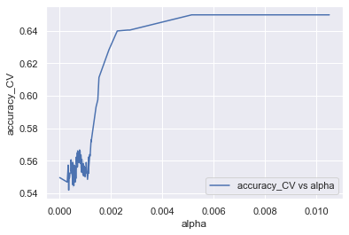

```python
sns.lineplot(x='alpha', y='accuracy_CV', data=output , color='b', label="accuracy_CV vs alpha")
plt.show()
```

```python
np.argmax(output['accuracy_CV'])
```

```
213
```

```python
output.iloc[np.argmax(output['accuracy_CV']),]
```

```
alpha          0.005143
accuracy_CV    0.649781
Name: 213, dtype: float64
```

```python
optimal_alpha = output.iloc[np.argmax(output['accuracy_CV']),0]
optimal_alpha
```

```
0.005142538659615947
```

We have our optimal alpha! ~0.00514 Let's optimize the model.

```python
optimal_DT = DecisionTreeClassifier(ccp_alpha=optimal_alpha)
optimal_DT.fit(X_train, y_train)
y_hat_optimized = optimal_DT.predict(X_test)
```

```python
print(confusion_matrix(y_test, y_hat_optimized))
```

```
[[  0 160]
 [  0 294]]
```

```python
print(classification_report(y_test, y_hat_optimized))
```

```
              precision    recall  f1-score   support

           0       0.00      0.00      0.00       160
           1       0.65      1.00      0.79       294

    accuracy                           0.65       454
   macro avg       0.32      0.50      0.39       454
weighted avg       0.42      0.65      0.51       454
```

Accuracy of 65% is better, and F1 score seems to have increased. Precision is the same. The main fishy thing here is that recall is now 100% meaing that the model is capturing true postives perfectly - it seems like we may be overfitting and looking at the confusion matrix it seems that this model is simply putting all observations as loan_status=1 (in fact, our target variable has an almost perfect 65/35 split so with accuracy of 65% we're pretty confident that this is what's happening).

Additionally, the statistics for loan_status=0 are all 0 now, which doesn't seem normal but we aren't sure what's going on.

```python
from sklearn.model_selection import cross_val_score
```

```python
accuracy = cross_val_score(estimator = optimal_DT, X = X_train, y = y_train, cv = 5 , scoring="accuracy" )
```

```python
accuracy
```

```
array([0.64835165, 0.65013774, 0.65013774, 0.65013774, 0.65013774])
```

```python
round(accuracy.mean(),3)
```

```
0.65
```

Even after optimizing, we're still not looking great with an accuracy of 65%

```python
df.columns
```

```
Index(['home_ownership', 'income', 'dti', 'fico', 'loan_status'], dtype='object')
```

```python
dtree= DecisionTreeClassifier(max_depth=2, ccp_alpha=0, min_samples_leaf=50)
dtree.fit(X_train, y_train)
yhat = dtree.predict(X_test)
```

```python
from sklearn import tree
```

```python
X_train.shape
```

```
(1816, 4)
```

```python
X_train.head()
```

|  | home_ownership | income | dti | fico |
| --- | --- | --- | --- | --- |
| 1377 | 1 | 108.000 | 15.96 | 685 |
| 1803 | 1 | 150.000 | 11.30 | 685 |
| 1431 | 1 | 54.000 | 15.38 | 665 |
| 1666 | 1 | 50.000 | 13.13 | 720 |
| 425 | 1 | 77.721 | 27.18 | 800 |

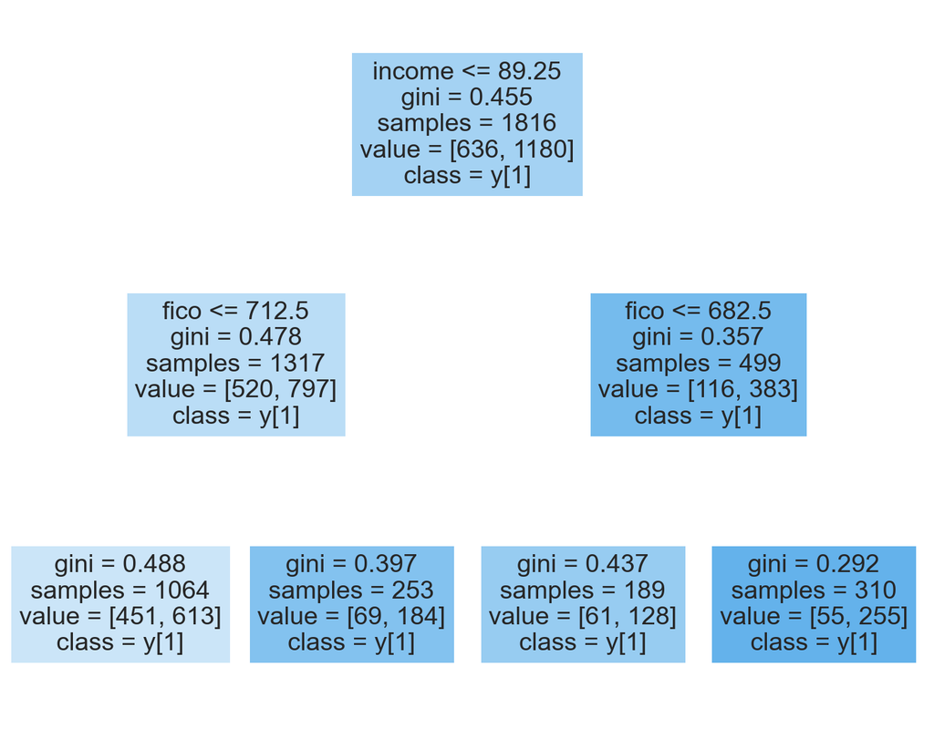

```python
fig = plt.figure(figsize=(25,20))
DT_plot = tree.plot_tree(dtree, feature_names=X_train.columns, filled=True, max_depth=4, class_names=True)
# left branch True
```

The best split in this tree (lowest gini number) is at fico <= 682.5.

Say there's an invidual with an income of 100 and a FICO score of 730. At the first split, income is greater than 89.25 so we go down the right side (left=true). At this split, our FICO score is greater than 682.5, so we go down the right side again. This leaves us at the leaf node to the furthest right, which gives us loan_status=1.

No we are not satisified, these gini numbers are pretty high. The closer we get to .5, the closer we are to doing no better than random.